# GSS Analysis about opinions on sexual behaviour in US from 1972 to 2016

Kyi Yeung Goh

31/12/2018

I prepared the data by using the latest GSS panel data. There are three functions (adapted from Jonah Gabry’s QMSS package) for time series analysis. Having extracted the relevant variables, I proceeded to remove those that were not relevant to the analysis i.e. those factors that represented “Others”. I included as well as recoded several variables:

**Year**: 31 years from 1972 to 2016  
**Homosex**: Recoded such that a score of 1 reflected a ‘not at all wrong’ **Conclerg**: Recoded such that a score of 1 reflect a ‘none at all’ response to the question, “I am going to name some institutions in this country. As far as the people running these institutions are concerned, would you say you have  
a great deal of confidence, only some confidence, or hardly any confidence at all in them?”. This is on a 4 point scale.  
**Sex**: Binary where 1 is female and 0 is men.  
**Age**: Unchanged.  
**Partyid**: A self-described strong republican is listed as 1 on an increasing scale that ends with a self-described strong democrat as 6.  
**Marital**: Never married as 1 and all other statuses including divorce or widowed as 0.  
**Educ**: Increasing from 0 to 20 for each increasing year of schooling.  
**Realinc**: Unchanged in real terms.  
**Race**: 1 for white and 0 for others.  
**Pray**: How often one prays a week, recoded with 1 as never and 6 as more than 1 a day.  
**Fund**: A variable that takes self-reported fundamentalism/liberalism of the religion. where 1 is fundementalist and others is 0.  
**Attend**: How often one attends religious services where never is 0 and 8 as several times as week. **Size**: Population size of area where respondent resides.

For more specific references, one can obtain the codebook here [http://gss.norc.org/Documents/codebook/Panel%20Codebook.pdf].

```r
# get means by year
by.year <- aggregate(subset(sub, sel = -year), list(year = sub$year), mean, na.rm = T)

# interpolate for some missing years
# add the extra years
by.year <- arrange(by.year, year)

# make a time series object by.year.ts and interpolate using na.approx
by.year.ts <- ts(by.year)
by.year.ts <- na.approx(by.year.ts)

by.year.ts <- as.data.frame(by.year.ts)

by.year.ts <- mutate(by.year.ts,
                     female_pct=female*100,
                     white_pct = white*100,
                     ba_pct = BA*100,
                     married_pct=married*100,
                     fund_pct=fund*100)
```

I then recoded several variables to obtain percentage terms. With female_pct, white_pct, ba_pct, married_pct and fund_pct representing the percentage of respondents for each survey wave.

## Some trends from panel data

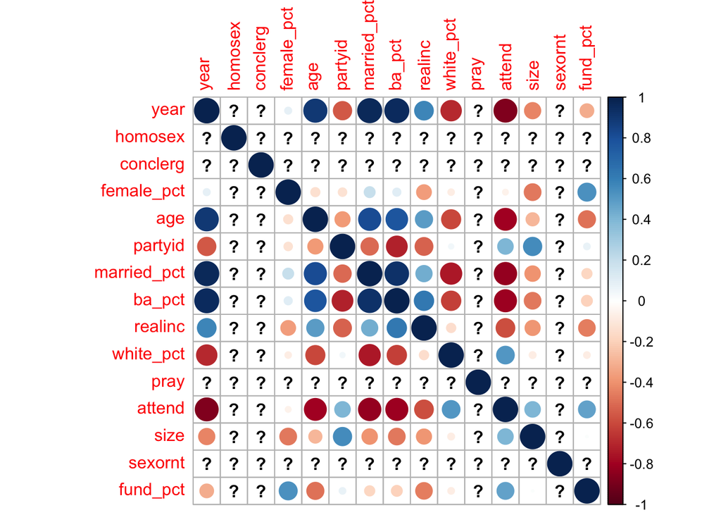

```r
# correlations
cor.vars <- c("year", "homosex","conclerg", "female_pct", "age", "partyid", "married_pct"
              , "ba_pct", "realinc","white_pct", "pray","attend","size","sexornt","fund_pct")

cor.dat <- by.year.ts[, cor.vars]

corrplot(cor(cor.dat))
```

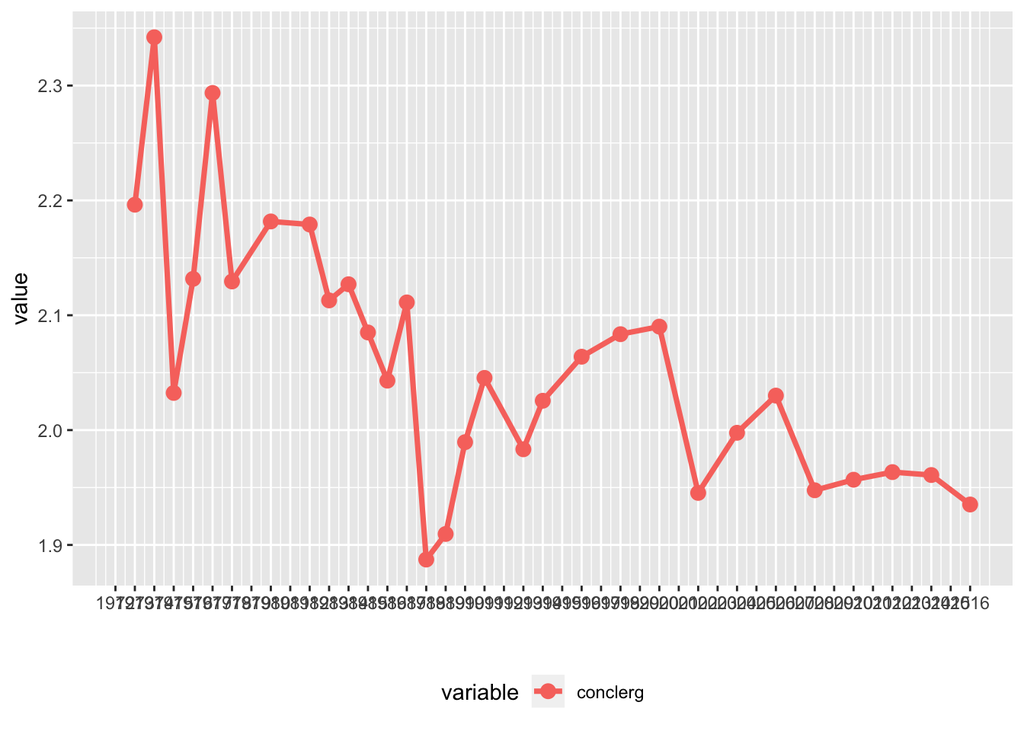

```r
keep.vars <- c("year", "homosex","conclerg", "female_pct", "age", "partyid", "married_pct"
               , "ba_pct", "realinc","white_pct", "pray","attend","size","fund_pct")

plot.dat <- meltMyTS(mv.ts.object = by.year.ts, time.var = "year", keep.vars = keep.vars)

(g_clerg_pct <- ggMyTS(df = plot.dat, varlist =
                         c("conclerg"))) #clergy trust over time
```

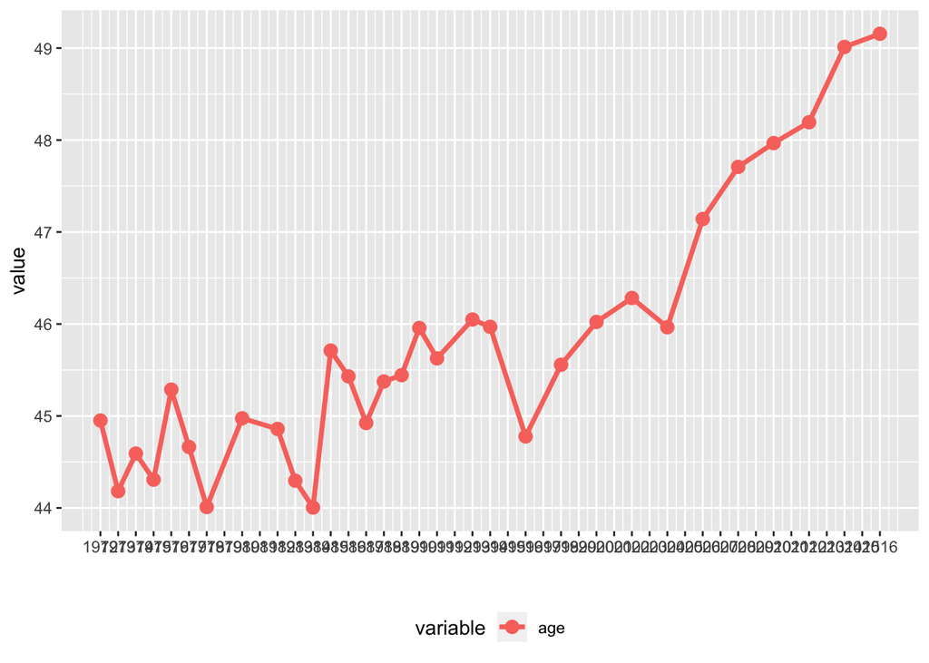

```r
(g_age <- ggMyTS(df = plot.dat, varlist =
                   c("age"))) #Average respondent age over time
```